# Introducción a SVM en R

“Support Vector Machine” (SVM) is a supervised machine learning algorithm which can be used for both classification or regression challenges. However, it is mostly used in classification problems. In this algorithm, we plot each data item as a point in n-dimensional space (where n is number of features you have) with the value of each feature being the value of a particular coordinate. Then, we perform classification by finding the hyper-plane that differentiate the two classes very well.

Support Vectors are simply the co-ordinates of individual observation. Support Vector Machine is a frontier which best segregates the two classes (hyper-plane/ line).

Tomado de: https://www.analyticsvidhya.com/blog/2017/09/understaing-support-vector-machine-example-code/

La librería de SVM que se usará para este taller es libSVM. Puede consultarse en la dirección https://www.csie.ntu.edu.tw/~cjlin/libsvm/

En R se debe cargar la librería e1071 que contiene funciones desarrolladas en el proyecto libSVM.

Existe un conjunto de datos de prueba para probar las SVM. Los datos corresponden a medidas de pétalos y pistilos de 3 diferentes clases de flores: Iris Setosa, Iris Versicolor e Iris Virginica. Este conjunto de datos se puede apreciar en la página:

https://en.wikipedia.org/wiki/Iris_flower_data_set.

El conjunto está listo para cargar en R:

```r
#install.packages("e1071")
library("e1071")

#data(iris)
#attach(iris)
```

## Regresión con SVM

Dado que las SVM definen un hiperplano en un espacio de coordenadas y un rango para poder separar diferentes clases en el caso de la clasificación, esto mismo puede hacerse para hacer una regresión, definiendo un hiperplano que modele los datos.

Para trabajar las regresiones con SVM, se mira un ejemplo con una serie de medidas. Los vectores ‘x’ y ‘y’ contienen una serie de coordenadas de puntos.

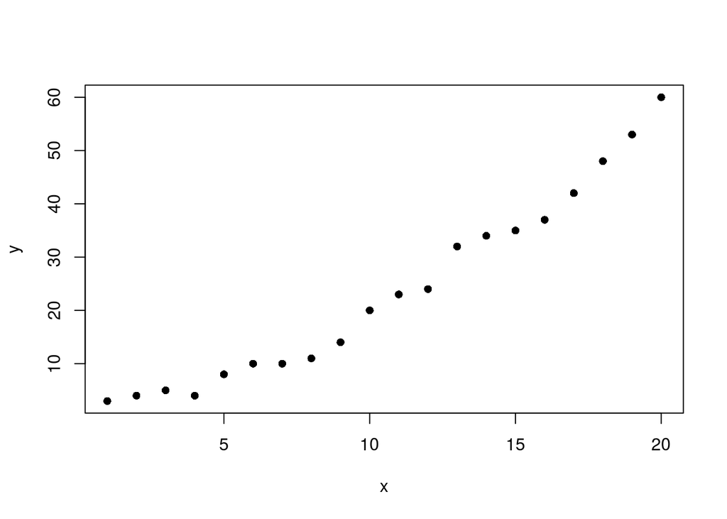

```r
x=c(1,2,3,4,5,6,7,8,9,10,11,12,13,14,15,16,17,18,19,20)
y=c(3,4,5,4,8,10,10,11,14,20,23,24,32,34,35,37,42,48,53,60)

#Create a data frame of the data
train=data.frame(x,y)

#print(train)

#Plot the dataset. pch=16 means black circles.
plot(train,pch=16)
```

Una comparación de la eficacia de una regresión normal con la que se logra usando las SVM se presenta a continuación:

```r
#Función para calcular RMS
rmse <- function(error)
{
  sqrt(mean(error^2))
}

#Linear regression
modellinear <- lm(y ~ x, train)

#Plot the model using abline
plot(train,pch=16)
abline(modellinear)
predictedY <- predict(modellinear, train)

errorlin <- modellinear$residuals  # same as data$Y - predictedY
predictionRMSlinear <- rmse(errorlin)   # 3.832974
print(predictionRMSlinear)
```

```
## [1] 3.832974
```

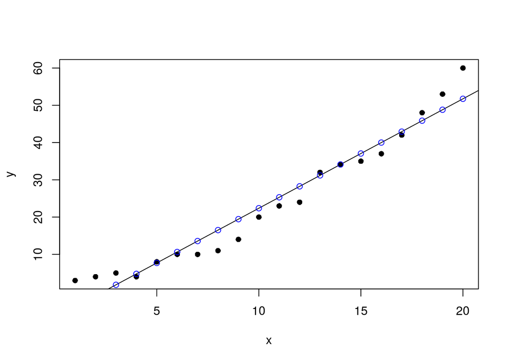

```r
# display the predictions
points(train$x, predictedY, col = "blue", pch=1)
```

Para hacer la regresión en SVM, se especifica que se quiere calcular una regresión por una relación entre una salida y y una entrada x, y se especifica cuáles son los datos para entrenar.

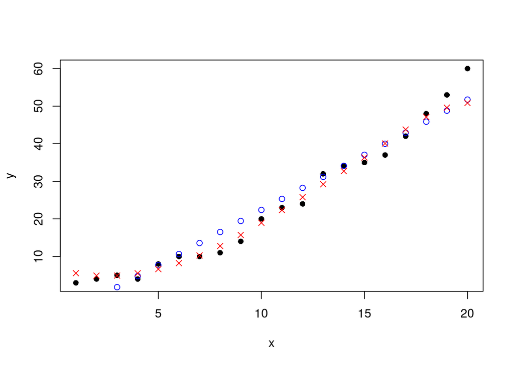

```r
model1 <- svm(formula = y ~ x , data = train, type = "eps-regression", cost = 1, gamma = 1, epsilon = 0.1)

predictedY1 <- predict(model1, train)
plot(train,pch=16)
abline(model1)
points(train$x, predictedY, col = "blue", pch=1)
points(train$x, predictedY1, col = "red", pch=4)
```

```r
error1 <- model1$residuals  # same as data$Y - predictedY
predictionRMSE1 <- rmse(error1)
print(predictionRMSE1)
```

```
## [1] 2.696281
```

```r
print(model1)
```

```
##
## Call:
## svm(formula = y ~ x, data = train, type = "eps-regression", cost = 1,
##     gamma = 1, epsilon = 0.1)
##
##
## Parameters:
##    SVM-Type:  eps-regression
##  SVM-Kernel:  radial
##        cost:  1
##       gamma:  1
##     epsilon:  0.1
##
##
## Number of Support Vectors:  9
```